# Catalogue Crossmatch

## Matching catalogues to the VAST Pilot Survey

This notebook gives an example of how to use vast-tools in a notebook environment to perform a crossmatch between a catalogue and the VAST Pilot Survey.

**Note** The settings and filters applied in this notebook, while sensible, are somewhat generic - always consider your science goals on what filters you want to make!

It is **highly recommended** that results from the VAST Pipeline are used and this is what will be primarily covered in this example. It is possible to run a search just using vast-tools but the results are nowhere near as rich as the pipeline - this is covered at the of this document.

### The VAST Pipeline

The pipeline hosted on the Nimbus server will contain the pipeline run for the full pilot survey. For a complete demo of what can be done with the vast-tools `Pipeline` class see the `vast-pipeline-example.ipynb` example notebook.

### The Imports

Below are the imports required for this example. The main imports required from vast-tools are the Pipeline and VASTMOCS objects. The Query object is for the vast-tools query option that is shown at the end of this notebook. Astropy objects are also imported as they are critical to perfoming the crossmatch.

```
from vasttools.moc import VASTMOCS
from vasttools.pipeline import Pipeline
from vasttools.query import Query
from mocpy import World2ScreenMPL
import matplotlib.pyplot as plt
from astropy import units as u
from astropy.coordinates import Angle, SkyCoord
```

### Catalogue selection

For this example we will be using the `Quasars and Active Galactic Nuclei (13th Ed.) (Veron+ 2010)` catalogue, which has the Vizier ID of `VII/258`.

**Note:** Of course your catalogue doesn't have to come from Vizier. If you have a `csv` or `FITS` file then simply load this data into a DataFrame, create a SkyCoord object and you'll be good to go.

To start our search, the first question we want to answer is:

*What sources from the catalogue are in the VAST Pilot Survey footprint?*

This can be efficiently answered by using the `query_vizier_vast_pilot()` method in VASTMOCS.

First we initialise the VASTMOCS object:

```
mocs = VASTMOCS()
```

We then use the query vizier method to obtain all the sources from the Veron catalogue which are contained within the footprint. It will likely take a bit of time to complete.

```
veron_vast_sources = mocs.query_vizier_vast_pilot('VII/258', max_rows=200000)
```

```
veron_vast_sources
```

*Table length=44704*

| _RAJ2000 deg float64 | _DEJ2000 deg float64 | recno int32 | Cl str1 | nR str1 | Name str17 | n_RAJ2000 str1 | RAJ2000 "h:m:s" str10 | DEJ2000 "d:m:s" str9 | l_z str1 | z float32 | Sp str4 | n_Vmag str1 | Vmag mag float32 | B-V mag float32 | r_z int16 |
| --- | --- | --- | --- | --- | --- | --- | --- | --- | --- | --- | --- | --- | --- | --- | --- |
| 0.005417 | -2.033333 | 1 | Q |  | FIRST J00000-0202 | R | 00 00 01.3 | -02 02 00 |  | 1.356 |  |  | 19.64 | -- | 179 |
| 0.027500 | 0.515278 | 7 | Q | * | SDSS J00001+0030 | O | 00 00 06.6 | +00 30 55 |  | 1.823 |  |  | 20.37 | 0.24 | 2068 |
| 0.034167 | 0.276389 | 8 | Q | * | SDSS J00001+0016 | O | 00 00 08.2 | +00 16 35 |  | 1.837 |  |  | 20.03 | 0.32 | 2068 |
| 0.050000 | 0.040000 | 18 | Q | * | PB 5669 | O | 00 00 12.0 | +00 02 24 |  | 0.479 |  |  | 18.06 | 0.13 | 50 |
| 0.051250 | -0.538889 | 19 | Q | * | SDSS J00002-0032 | O | 00 00 12.3 | -00 32 20 |  | 1.436 |  |  | 20.34 | 0.31 | 2068 |
| 0.056667 | -2.172222 | 21 | Q |  | Q 2357-024 | O | 00 00 13.6 | -02 10 20 | * | 1.450 |  |  | 19.40 | -- | 2677 |
| 0.057500 | -0.912778 | 22 | Q | * | SDSS J00002-0054 | O | 00 00 13.8 | -00 54 46 |  | 1.836 |  |  | 20.10 | 0.24 | 2068 |
| 0.061667 | -1.175000 | 23 | Q | * | SDSS J00002-0110 | O | 00 00 14.8 | -01 10 30 |  | 1.890 |  |  | 19.31 | 0.19 | 2068 |
| 0.064583 | 0.879444 | 24 | Q | * | SDSS J00002+0052 | O | 00 00 15.5 | +00 52 46 |  | 1.848 |  |  | 19.55 | 0.19 | 2068 |
| ... | ... | ... | ... | ... | ... | ... | ... | ... | ... | ... | ... | ... | ... | ... | ... |
| 359.788333 | 0.961389 | 168925 | A | * | SDSS J23591+0057 | O | 23 59 09.2 | +00 57 41 |  | 1.158 |  |  | 21.45 | 0.38 | 2068 |
| 359.795000 | -4.127222 | 168926 | A |  | IC 1524 | O | 23 59 10.8 | -04 07 38 |  | 0.019 | S1.0 |  | 14.50 | -- | 1610 |
| 359.799167 | -8.280000 | 168927 | A |  | NVSS J23591-0816 | O | 23 59 11.8 | -08 16 48 |  | 0.049 | S | R | 15.10 | -- | 1517 |
| 359.808333 | -0.343889 | 168928 | A | * | SDSS J23592-0020 | O | 23 59 14.0 | -00 20 38 |  | 0.521 |  |  | 19.90 | 0.33 | 2068 |
| 359.830000 | -0.522500 | 168930 | A | * | SDSS J23593-0031 | O | 23 59 19.2 | -00 31 21 |  | 0.836 |  |  | 20.99 | 0.19 | 2068 |
| 359.837500 | 0.981944 | 168932 | A | * | SDSS J23593+0058 | O | 23 59 21.0 | +00 58 55 |  | 0.541 |  |  | 20.94 | 0.47 | 2068 |
| 359.859583 | -0.797222 | 168933 | A | * | SDSS J23594-0047 | O | 23 59 26.3 | -00 47 50 |  | 0.396 |  |  | 19.49 | 0.19 | 2068 |
| 359.934167 | 1.638333 | 168936 | A | * | Q 2357+0121 | O | 23 59 44.2 | +01 38 18 |  | 0.090 | S |  | 17.90 | -- | 762 |
| 359.968750 | -0.508889 | 168938 | A | * | Q 2357-007 | O | 23 59 52.5 | -00 30 32 | * | 0.210 |  |  | 18.50 | -- | 2677 |
| 359.972500 | -9.615278 | 168939 | A | * | SDSS J23598-0936 | O | 23 59 53.4 | -09 36 55 |  | 0.359 | S1 |  | 19.12 | 0.45 | 3 |

We see that 44,704 sources are within the VAST Pilot Survey footprint.

**Tip:** The table returned above is an astropy.table. This can be converted to pandas by using `veron_vast_sources = veron_vast_sources.to_pandas()`.

These can be plotted along with the VAST Pilot Survey footprint using the MOC. See the vast-mocs-example notebook for more on using MOCS and the `Wordl2ScreenMPL` method.

```
from astropy.visualization.wcsaxes.frame import EllipticalFrame

fig = plt.figure(figsize=(16,8))

# Load the Epoch 1 MOC file to use
epoch1_moc = mocs.load_pilot_epoch_moc('1')

#
with World2ScreenMPL(
    fig,
    fov=320 * u.deg,
    center=SkyCoord(0, 0, unit='deg', frame='icrs'),
    coordsys="icrs",
    rotation=Angle(0, u.degree),
) as wcs:
    ax = fig.add_subplot(111, projection=wcs, frame_class=EllipticalFrame)
    ax.set_title("Veron Catalogue Sources in the VAST Pilot Survey")
    ax.grid(color="black", linestyle="dotted")
    epoch1_moc.fill(ax=ax, wcs=wcs, alpha=0.5, fill=True, linewidth=0, color="#00bb00")
    epoch1_moc.border(ax=ax, wcs=wcs, alpha=0.5, color="black")
    ax.scatter(
        veron_vast_sources['_RAJ2000'],
        veron_vast_sources['_DEJ2000'],
        transform=ax.get_transform('world'),
        zorder=10,
        s=3
    )

fig
```

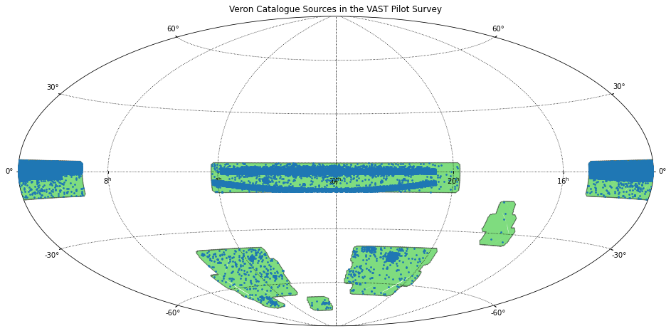

### Loading the VAST Pipeline Data

Now the results of the VAST Pipeline need to be loaded. This example will not give full details of the Pipeline class, but please refer to the `vast-pipeline-example.ipynb` example notebook for a full example and description.

We'll be using the full VAST Pilot Survey pipeline containing epochs 0–13 (a test version called `tiles_corrected`).

```
# below I suppress DeprecationWarnings due to ipykernel bug and an astropy warning due to FITS header warnings.
import warnings
from astropy.utils.exceptions import AstropyWarning
warnings.simplefilter('ignore', category=AstropyWarning)
warnings.filterwarnings("ignore", category=DeprecationWarning)
```

```
# define pipeline object
pipe = Pipeline()
# load the run
pipe_run = pipe.load_run('tiles_corrected')
```

We now have access to the unique sources found by the pipeline:

```
pipe_run.sources.head()
```

| id | wavg_ra | wavg_dec | avg_compactness | min_snr | max_snr | wavg_uncertainty_ew | wavg_uncertainty_ns | avg_flux_int | avg_flux_peak | max_flux_peak | ... | n_neighbour_dist | vs_abs_significant_max_peak | m_abs_significant_max_peak | vs_abs_significant_max_int | m_abs_significant_max_int | n_measurements | n_selavy | n_forced | n_siblings | n_relations |
| --- | --- | --- | --- | --- | --- | --- | --- | --- | --- | --- | --- | --- | --- | --- | --- | --- | --- | --- | --- | --- | --- |
| 3154268 | 256.680374 | -31.633248 | 1.283746 | 7.023084 | 9.908238 | 0.000131 | 0.000131 | 10.155522 | 8.054022 | 9.744 | ... | 0.004406 | 0.0 | 0.0 | 0.0 | 0.0 | 8 | 7 | 1 | 1 | 0 |
| 3154269 | 256.768092 | -32.291573 | 1.323703 | 7.360183 | 12.238208 | 0.000131 | 0.000131 | 13.821750 | 10.513000 | 16.082 | ... | 0.018514 | 0.0 | 0.0 | 0.0 | 0.0 | 8 | 8 | 0 | 0 | 0 |
| 3154270 | 256.877497 | -32.994510 | 1.652192 | 4.206989 | 5.507463 | 0.000111 | 0.000111 | 2.737171 | 2.125296 | 4.428 | ... | 0.000899 | 0.0 | 0.0 | 0.0 | 0.0 | 8 | 2 | 6 | 1 | 1 |
| 3154271 | 256.994382 | -34.269667 | 1.078640 | 5.091991 | 5.091991 | 0.000104 | 0.000104 | 2.715779 | 2.669529 | 4.705 | ... | 0.031288 | 0.0 | 0.0 | 0.0 | 0.0 | 8 | 1 | 7 | 0 | 0 |
| 3154272 | 257.064242 | -30.605582 | 1.265750 | 13.853442 | 34.843492 | 0.000104 | 0.000104 | 24.911125 | 19.716750 | 21.150 | ... | 0.005057 | 0.0 | 0.0 | 0.0 | 0.0 | 8 | 8 | 0 | 1 | 0 |

5 rows × 31 columns

### Performing the Crossmatch

The crossmatch can be performed using the astropy `match_to_catalog_sky` function. The first step is to create the sky coord objects for each catalogue. First the Veron catalog which was already obtained above:

```
# Unfortunately we cannot use guess_from_table for the Vizier results, so we construct manually
veron_skycoord = SkyCoord(veron_vast_sources['_RAJ2000'], veron_vast_sources['_DEJ2000'], unit=(u.deg, u.deg))
veron_names = veron_vast_sources['Name'].tolist()
```

and then by default the pipeline run object has the default sources saved as a sky coord object as `pipe_run.sources_skycoord`:

```
pipe_run.sources_skycoord
```

```
<SkyCoord (ICRS): (ra, dec) in deg
    [(256.68037425, -31.63324799), (256.76809184, -32.29157276),
     (256.87749704, -32.99451047), ..., ( 25.085549  , -70.881779  ),
     ( 23.102247  , -71.605088  ), ( 27.338584  , -72.877979  )]>
```

Now the crossmatching can be performed. See https://docs.astropy.org/en/stable/coordinates/matchsep.html#astropy-coordinates-matching for details on the astropy functions and outputs.

```
idx, d2d, d3d = veron_skycoord.match_to_catalog_sky(pipe_run.sources_skycoord)
radius_limit = 15 * u.arcsec
(d2d <= radius_limit).sum()
```

```
5048
```

From above we can see that 5048 Veron objects have a match to the pipeline sources. If you wish you could merge the results together:

```
# Convert Veron to pandas first
veron_vast_sources_pd = veron_vast_sources.to_pandas()
# Create a d2d mask
d2d_mask = d2d <= radius_limit
# Select the crossmatches less than 15 arcsec
veron_crossmatch_result_15asec = veron_vast_sources_pd.loc[d2d_mask].copy()
# Append the id and distance of the VAST crossmatch to the veron sources
veron_crossmatch_result_15asec['vast_xmatch_id'] = pipe_run.sources.iloc[idx[d2d_mask]].index.values
veron_crossmatch_result_15asec['vast_xmatch_d2d_asec'] = d2d[d2d_mask].arcsec
# Join the result
veron_crossmatch_result_15asec = veron_crossmatch_result_15asec.merge(pipe_run.sources, how='left', left_on='vast_xmatch_id', right_index=True, suffixes=("_veron", "_vast"))
veron_crossmatch_result_15asec
```

|  | _RAJ2000 | _DEJ2000 | recno | Cl | nR | Name | n_RAJ2000 | RAJ2000 | DEJ2000 | l_z | ... | n_neighbour_dist | vs_abs_significant_max_peak | m_abs_significant_max_peak | vs_abs_significant_max_int | m_abs_significant_max_int | n_measurements | n_selavy | n_forced | n_siblings | n_relations |
| --- | --- | --- | --- | --- | --- | --- | --- | --- | --- | --- | --- | --- | --- | --- | --- | --- | --- | --- | --- | --- | --- |
| 0 | 0.005417 | -2.033333 | 1 | Q |  | FIRST J00000-0202 | R | 00 00 01.3 | -02 02 00 |  | ... | 0.000135 | 5.985905 | 5.058374 | 5.734354 | 6.852469 | 9 | 8 | 1 | 0 | 1 |
| 10 | 0.072917 | -8.856389 | 28 | Q |  | FIRST J00002-0851 | O | 00 00 17.5 | -08 51 23 |  | ... | 0.008433 | 11.316395 | 0.585097 | 0.000000 | 0.000000 | 10 | 10 | 0 | 0 | 0 |
| 19 | 0.174583 | -2.489722 | 55 | Q |  | Q 2358-0246 | O | 00 00 41.9 | -02 29 23 |  | ... | 0.000106 | 9.923203 | 7.243259 | 9.337049 | 7.287610 | 10 | 9 | 1 | 1 | 1 |
| 27 | 0.210833 | -10.365556 | 71 | Q |  | FIRST J00008-1021 | O | 00 00 50.6 | -10 21 56 |  | ... | 0.041970 | 0.000000 | 0.000000 | 0.000000 | 0.000000 | 7 | 7 | 0 | 0 | 0 |
| 28 | 0.215000 | 0.200833 | 72 | Q |  | SDSS J00008+0012 | O | 00 00 51.6 | +00 12 03 |  | ... | 0.000052 | 4.325716 | 0.722804 | 0.000000 | 0.000000 | 9 | 8 | 1 | 0 | 2 |
| ... | ... | ... | ... | ... | ... | ... | ... | ... | ... | ... | ... | ... | ... | ... | ... | ... | ... | ... | ... | ... | ... |
| 44685 | 359.386667 | -0.479167 | 168903 | A | * | SDSS J23575-0028 | O | 23 57 32.8 | -00 28 45 |  | ... | 0.037219 | 0.000000 | 0.000000 | 0.000000 | 0.000000 | 9 | 1 | 8 | 0 | 0 |
| 44686 | 359.432500 | 0.655000 | 168904 | A |  | SDSS J23577+0039 | O | 23 57 43.8 | +00 39 18 |  | ... | 0.000071 | 0.000000 | 0.000000 | 0.000000 | 0.000000 | 9 | 9 | 0 | 2 | 1 |
| 44687 | 359.433750 | -0.174722 | 168905 | A |  | SDSS J23577-0010 | O | 23 57 44.1 | -00 10 29 |  | ... | 0.000056 | 0.000000 | 0.000000 | 0.000000 | 0.000000 | 9 | 9 | 0 | 1 | 1 |
| 44695 | 359.795000 | -4.127222 | 168926 | A |  | IC 1524 | O | 23 59 10.8 | -04 07 38 |  | ... | 0.000332 | 0.000000 | 0.000000 | 0.000000 | 0.000000 | 10 | 9 | 1 | 0 | 1 |
| 44696 | 359.799167 | -8.280000 | 168927 | A |  | NVSS J23591-0816 | O | 23 59 11.8 | -08 16 48 |  | ... | 0.009866 | 0.000000 | 0.000000 | 0.000000 | 0.000000 | 10 | 10 | 0 | 3 | 0 |

5048 rows × 49 columns

With the crossmatches in hand you can now start to do any kind of analysis you wish to perform. For example we can perform a quick check to see if the pipeline has picked out any of these sources as having significant two-epoch variability:

```
veron_crossmatch_result_15asec[veron_crossmatch_result_15asec['m_abs_significant_max_peak'] > 0.00]
```

|  | _RAJ2000 | _DEJ2000 | recno | Cl | nR | Name | n_RAJ2000 | RAJ2000 | DEJ2000 | l_z | ... | n_neighbour_dist | vs_abs_significant_max_peak | m_abs_significant_max_peak | vs_abs_significant_max_int | m_abs_significant_max_int | n_measurements | n_selavy | n_forced | n_siblings | n_relations |
| --- | --- | --- | --- | --- | --- | --- | --- | --- | --- | --- | --- | --- | --- | --- | --- | --- | --- | --- | --- | --- | --- |
| 0 | 0.005417 | -2.033333 | 1 | Q |  | FIRST J00000-0202 | R | 00 00 01.3 | -02 02 00 |  | ... | 0.000135 | 5.985905 | 5.058374 | 5.734354 | 6.852469 | 9 | 8 | 1 | 0 | 1 |
| 10 | 0.072917 | -8.856389 | 28 | Q |  | FIRST J00002-0851 | O | 00 00 17.5 | -08 51 23 |  | ... | 0.008433 | 11.316395 | 0.585097 | 0.000000 | 0.000000 | 10 | 10 | 0 | 0 | 0 |
| 19 | 0.174583 | -2.489722 | 55 | Q |  | Q 2358-0246 | O | 00 00 41.9 | -02 29 23 |  | ... | 0.000106 | 9.923203 | 7.243259 | 9.337049 | 7.287610 | 10 | 9 | 1 | 1 | 1 |
| 28 | 0.215000 | 0.200833 | 72 | Q |  | SDSS J00008+0012 | O | 00 00 51.6 | +00 12 03 |  | ... | 0.000052 | 4.325716 | 0.722804 | 0.000000 | 0.000000 | 9 | 8 | 1 | 0 | 2 |
| 59 | 0.458333 | -1.994444 | 152 | Q |  | UM 196 | O | 00 01 50.0 | -01 59 40 |  | ... | 0.000467 | 11.243905 | 0.313065 | 17.583186 | 0.876370 | 9 | 9 | 0 | 7 | 2 |
| ... | ... | ... | ... | ... | ... | ... | ... | ... | ... | ... | ... | ... | ... | ... | ... | ... | ... | ... | ... | ... | ... |
| 44584 | 356.690000 | 0.650000 | 168717 | A |  | SDSS J23467+0039 | O | 23 46 45.6 | +00 39 00 |  | ... | 0.006970 | 6.963963 | 0.397822 | 4.328959 | 0.433683 | 8 | 8 | 0 | 1 | 0 |
| 44586 | 356.751667 | -0.447500 | 168720 | A |  | MARK 540 | O | 23 47 00.4 | -00 26 51 |  | ... | 0.000065 | 26.489516 | 1.241460 | 6.992881 | 0.642963 | 8 | 8 | 0 | 2 | 1 |
| 44623 | 357.711250 | -0.480000 | 168786 | A |  | SDSS J23508-0028 | O | 23 50 50.7 | -00 28 48 |  | ... | 0.000201 | 17.786942 | 0.465473 | 7.078799 | 0.204905 | 8 | 8 | 0 | 1 | 1 |
| 44641 | 358.277083 | -9.430000 | 168823 | A |  | FIRST J23531-0925 | R | 23 53 06.5 | -09 25 48 |  | ... | 0.000158 | 4.524132 | 0.914640 | 0.000000 | 0.000000 | 10 | 8 | 2 | 1 | 1 |
| 44661 | 358.741667 | 1.590278 | 168859 | A | * | Q 2352+0118 |  | 23 54 58.0 | +01 35 25 |  | ... | 0.006295 | 6.260565 | 0.977011 | 6.260565 | 0.977011 | 8 | 3 | 5 | 3 | 0 |

2086 rows × 49 columns

And remember you can use the vast-toools source tools to view any source as in the other example notebooks:

```
# Get the first VAST source above from the table above
first_source_id = veron_crossmatch_result_15asec[veron_crossmatch_result_15asec['m_abs_significant_max_peak'] > 0.00].iloc[0].vast_xmatch_id
first_source = pipe_run.get_source(first_source_id)
first_source.plot_lightcurve(min_points=1)
```

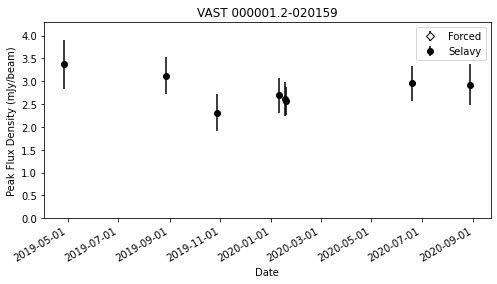

```
first_source.show_all_png_cutouts(columns=5, figsize=(12,7), size=Angle(2. * u.arcmin))
```

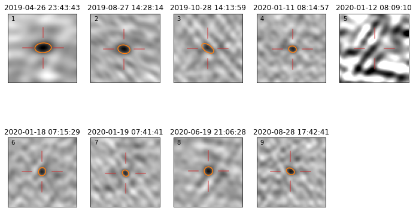

### Filtering the Pipeline Sources (Optional)

The example above has used all the sources from the pipeline results, but these may need to be filtered further to improve results. For example Below is an example of how to filter the sources.

```
my_query_string = (
    "n_measurements >= 3 "
    "& n_selavy >= 2 "
    "& n_neighbour_dist > 1./60. "
    "& 0.8 < avg_compactness < 1.4 "
    "& n_relations == 0 "
    "& max_snr > 7.0"
)

pipe_run_filtered_sources = pipe_run.sources.query(my_query_string)
pipe_run_filtered_sources
```

| id | wavg_ra | wavg_dec | avg_compactness | min_snr | max_snr | wavg_uncertainty_ew | wavg_uncertainty_ns | avg_flux_int | avg_flux_peak | max_flux_peak | ... | n_neighbour_dist | vs_abs_significant_max_peak | m_abs_significant_max_peak | vs_abs_significant_max_int | m_abs_significant_max_int | n_measurements | n_selavy | n_forced | n_siblings | n_relations |
| --- | --- | --- | --- | --- | --- | --- | --- | --- | --- | --- | --- | --- | --- | --- | --- | --- | --- | --- | --- | --- | --- |
| 3154269 | 256.768092 | -32.291573 | 1.323703 | 7.360183 | 12.238208 | 0.000131 | 0.000131 | 13.821750 | 10.513000 | 16.082000 | ... | 0.018514 | 0.000000 | 0.000000 | 0.000000 | 0.000000 | 8 | 8 | 0 | 0 | 0 |
| 3154274 | 257.123241 | -33.290413 | 1.043619 | 5.383128 | 7.515734 | 0.000131 | 0.000131 | 3.478531 | 3.365781 | 4.299000 | ... | 0.033579 | 0.000000 | 0.000000 | 0.000000 | 0.000000 | 8 | 6 | 2 | 0 | 0 |
| 3154275 | 257.150280 | -34.244257 | 1.100210 | 27.437848 | 56.402649 | 0.000100 | 0.000100 | 36.091500 | 33.053375 | 42.584000 | ... | 0.055755 | 14.525015 | 0.415325 | 7.691956 | 0.356892 | 8 | 8 | 0 | 0 | 0 |
| 3154276 | 257.208633 | -33.706400 | 1.137502 | 5.171521 | 8.311847 | 0.000130 | 0.000130 | 4.048633 | 3.648008 | 4.771000 | ... | 0.068295 | 0.000000 | 0.000000 | 0.000000 | 0.000000 | 8 | 6 | 2 | 0 | 0 |
| 3154280 | 257.385381 | -29.637161 | 1.223584 | 4.914062 | 8.870000 | 0.000136 | 0.000136 | 4.392721 | 3.942971 | 10.097926 | ... | 0.090124 | 0.000000 | 0.000000 | 0.000000 | 0.000000 | 8 | 6 | 2 | 0 | 0 |
| ... | ... | ... | ... | ... | ... | ... | ... | ... | ... | ... | ... | ... | ... | ... | ... | ... | ... | ... | ... | ... | ... |
| 4187751 | 28.447701 | -71.461967 | 1.170482 | 5.262097 | 7.271111 | 0.000120 | 0.000120 | 1.285112 | 1.173112 | 1.636000 | ... | 0.038168 | 0.000000 | 0.000000 | 0.000000 | 0.000000 | 8 | 4 | 4 | 0 | 0 |
| 4187753 | 27.868811 | -73.366549 | 0.961813 | 6.240385 | 7.564972 | 0.000106 | 0.000106 | 1.126009 | 1.138259 | 1.913642 | ... | 0.075690 | 0.000000 | 0.000000 | 0.000000 | 0.000000 | 8 | 2 | 6 | 0 | 0 |
| 4187767 | 29.119577 | -76.484675 | 1.304243 | 7.550373 | 26.512988 | 0.000108 | 0.000108 | 19.405860 | 15.354985 | 19.670880 | ... | 0.039074 | 0.000000 | 0.000000 | 0.000000 | 0.000000 | 8 | 7 | 1 | 0 | 0 |
| 4187768 | 12.644212 | -69.259777 | 1.145142 | 12.137412 | 22.289985 | 0.000116 | 0.000116 | 17.166571 | 15.038286 | 19.649000 | ... | 0.053142 | 5.239442 | 0.475465 | 0.000000 | 0.000000 | 7 | 7 | 0 | 0 | 0 |
| 4187771 | 18.395954 | -69.143241 | 1.011926 | 6.956522 | 17.792143 | 0.000111 | 0.000111 | 13.555196 | 13.376696 | 14.852000 | ... | 0.123835 | 0.000000 | 0.000000 | 0.000000 | 0.000000 | 8 | 7 | 1 | 0 | 0 |

160540 rows × 31 columns

You can either: * apply this to the crossmatch results above, or * substitute `pipe_run_filtered_sources` into the complete crossmatch process above in the place of `my_run.sources` (you need to create a new SkyCoord object first).

```
pipe_run_filtered_sources_skycoord = pipe_run.get_sources_skycoord(user_sources=pipe_run_filtered_sources)
pipe_run_filtered_sources_skycoord
```

```
<SkyCoord (ICRS): (ra, dec) in deg
    [(256.76809184, -32.29157276), (257.12324084, -33.29041257),
     (257.15028042, -34.2442568 ), ..., ( 29.11957731, -76.48467529),
     ( 12.64421225, -69.25977672), ( 18.39595379, -69.14324061)]>
```

### Finding All Crossmatches Between Sources

The crossmatch above only finds the nearest neighbour to the sources in your catalogue. Astropy also offers the functionality to find all matches between objects within a defined radius. See https://docs.astropy.org/en/stable/coordinates/matchsep.html#searching-around-coordinates for full details. This is done by performing the below, using the 15 arcsec radius:

```
idx_vast, idx_veron, d2d, d3d = veron_skycoord.search_around_sky(pipe_run.sources_skycoord, 15 * u.arcsec)
```

A merged dataframe of this crossmatch can be made like that below. Note there are multiple matches to sources so this will generate duplicate sources within the dataframe.

```
# Create a subset dataframe of the Veron sources with a match
veron_search_around_results_15asec = veron_vast_sources_pd.iloc[idx_veron].copy()
# Add the VAST d2d and match id columns
veron_search_around_results_15asec['vast_xmatch_d2d_asec'] = d2d.arcsec
veron_search_around_results_15asec['vast_xmatch_id'] = pipe_run.sources.iloc[idx_vast].index.values
# Perform the merge
veron_search_around_results_15asec = veron_search_around_results_15asec.merge(pipe_run.sources, how='left', left_on='vast_xmatch_id', right_index=True, suffixes=("_veron", "_vast"))
veron_search_around_results_15asec
```

|  | _RAJ2000 | _DEJ2000 | recno | Cl | nR | Name | n_RAJ2000 | RAJ2000 | DEJ2000 | l_z | ... | n_neighbour_dist | vs_abs_significant_max_peak | m_abs_significant_max_peak | vs_abs_significant_max_int | m_abs_significant_max_int | n_measurements | n_selavy | n_forced | n_siblings | n_relations |
| --- | --- | --- | --- | --- | --- | --- | --- | --- | --- | --- | --- | --- | --- | --- | --- | --- | --- | --- | --- | --- | --- |
| 8937 | 137.320833 | 0.139722 | 34093 | Q |  | SDSS J09092+0008 | O | 09 09 17.0 | +00 08 23 |  | ... | 0.024720 | 0.000000 | 0.000000 | 0.000000 | 0.000000 | 14 | 14 | 0 | 0 | 0 |
| 37257 | 138.315417 | 0.745278 | 143648 | A |  | SDSS J09132+0044 | O | 09 13 15.7 | +00 44 43 |  | ... | 0.003119 | 19.560179 | 0.276275 | 4.814783 | 0.272221 | 14 | 14 | 0 | 14 | 0 |
| 9218 | 139.086250 | -2.743611 | 35413 | Q |  | PKS 0913-025 | O | 09 16 20.7 | -02 44 37 |  | ... | 0.003173 | 321.009618 | 0.965813 | 348.174636 | 0.894915 | 14 | 6 | 8 | 6 | 0 |
| 9223 | 139.115417 | -0.086389 | 35443 | Q |  | SDSS J09164-0005 | O | 09 16 27.7 | -00 05 11 |  | ... | 0.035137 | 7.895561 | 0.224765 | 4.578869 | 0.483304 | 14 | 14 | 0 | 0 | 0 |
| 9551 | 141.017917 | -0.118889 | 36970 | Q |  | SDSS J09240-0007 | O | 09 24 04.3 | -00 07 08 |  | ... | 0.019196 | 4.838249 | 0.201568 | 0.000000 | 0.000000 | 14 | 14 | 0 | 0 | 0 |
| ... | ... | ... | ... | ... | ... | ... | ... | ... | ... | ... | ... | ... | ... | ... | ... | ... | ... | ... | ... | ... | ... |
| 43380 | 325.652083 | -42.912222 | 166569 | A | * | Q 2139-4308 | O | 21 42 36.5 | -42 54 44 |  | ... | 0.036547 | 0.000000 | 0.000000 | 0.000000 | 0.000000 | 8 | 5 | 3 | 0 | 0 |
| 28661 | 321.235833 | -43.900556 | 120942 | Q | * | HB 34 | O | 21 24 56.6 | -43 54 02 |  | ... | 0.096738 | 0.000000 | 0.000000 | 0.000000 | 0.000000 | 8 | 2 | 6 | 0 | 0 |
| 32453 | 348.538750 | -44.930278 | 129400 | Q |  | PKS 2311-452 | O | 23 14 09.3 | -44 55 49 |  | ... | 0.003106 | 523.185145 | 1.943131 | 232.385628 | 1.869067 | 7 | 1 | 6 | 1 | 0 |
| 27580 | 306.085833 | -57.395556 | 119568 | Q |  | PKS 2020-57 | O | 20 24 20.6 | -57 23 44 |  | ... | 0.000432 | 1186.719622 | 1.869458 | 593.489514 | 1.780289 | 7 | 4 | 3 | 4 | 1 |
| 30231 | 330.410000 | -56.775278 | 123576 | Q |  | 1WGA J2201.6-5646 | O | 22 01 38.4 | -56 46 31 |  | ... | 0.000366 | 138.069167 | 11.216223 | 98.094743 | 24.100879 | 8 | 7 | 1 | 7 | 3 |

7099 rows × 49 columns

This is the end of the example of performing a catalogue crossmatch using the VAST Pipeline. The information below this point is about using the vast-tools query method to find sources from the pilot survey if a pipeline run is not available. A pipeline run should be used whenever possible due to the superior quality of data it generates.

## Find VAST Matches Using VAST Tools

If a pipeline run isn't available you can use VAST Tools to match to the **VAST Pilot Survey only**.

Here the same Veron dataframe that was created in the pipeline section above is used.

The first step is to construct a Query to see how many sources have matches to selavy componentst in the VAST Pilot Survey. In the Query definition below we use the `matches_only` argument. This means that only those sources that have an actual match are returned. I also explicitly do not select RACS to search here, I'm only interested in the VAST Pilot data, so I select `all-vast`. Note you must pre-create the output directory for the query if you intend to use it.

```
veron_query = Query(
    coords=veron_skycoord,
    source_names=veron_names,
    epochs='all-vast',
    max_sep=1.5,
    crossmatch_radius=10.0,
    base_folder='/data/vast-survey/pilot/',
    matches_only=True,
    no_rms=True,
    output_dir='veron-vast-crossmatching',
)
```

And run `find_sources` - again a warning that this will take a little while to process.

```
veron_query.find_sources()
```

We can check the results attribute to see how many sources return a match.

```
veron_query.results.shape[0]
```

```
4664
```

### Using the results

4664 sources have returned a match in the VAST Pilot Survey in any epoch.

We can create new skycoord and name objects ready for a new query:

```
matches_mask = [i in (veron_query.results) for i in veron_vast_sources['Name']]
matched_names = veron_vast_sources['Name'][matches_mask].tolist()
matched_skycoords = veron_skycoord[matches_mask]
```

Or loop through and save all the measurements for each source.

```
# for i in veron_query.results:
#     i.write_measurements()
```

While you can explore the sources as normal, for example

```
my_source = veron_query.results['1AXG J134412+0016']
lc = my_source.plot_lightcurve()
lc
```

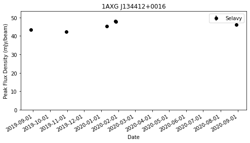

```
cutout = my_source.show_png_cutout('1')
cutout
```

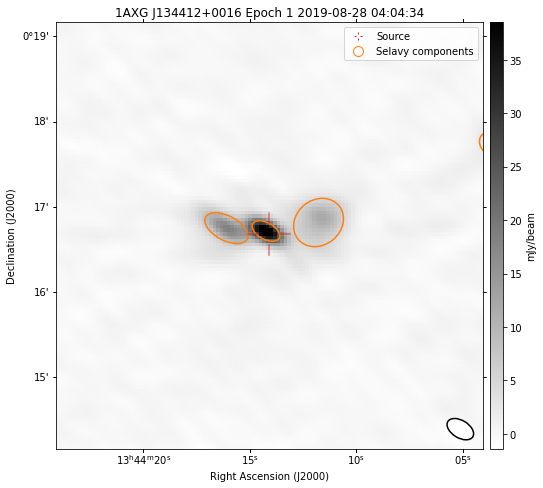

it's not recommended to produce cut outs for all sources in the notebook as this will start to take a lot of memory and be quite slow. If you'd like to do this then please use the `find_sources.py` script.

### VAST Tools Variability

Unlike the Pipeline, the sources returned using this method do not contain any of the caluclated metrics. However, you can also perform some rudimentary variablility analysis on the results if you wish.

I would recommened using the VAST Pipeline if possible for this kind of analysis as the associations will be much better and the you'll get a lot more information, but nevertheless this is an example of what you **can** do with the data from vast-tools.

In the code below I create a dataframe from the query results (which is a pandas series) and assign it to `variables_df` and define a function that returns the eta and V metrics for each source when passed through `.apply()`. These are then assigned to new `eta` and `v` columns in the `variables_df` dataframe.

```
import pandas as pd

def get_variable_metrics(row):
    """
    Function to return the eta and v metrics using apply.
    """
    return row['object'].calc_eta_and_v_metrics()

# create the variables_df dataframe, rename the column holding the objects as 'object'
variables_df = pd.DataFrame(veron_query.results).rename(columns={'name':'object'})
# obtain the metrics
variables_df[['eta', 'v']] = variables_df.apply(get_variable_metrics, result_type='expand', axis=1)
```

We can then, for example, plot the log eta distribution, making sure we choose sources that have more than 2 detections.

```
%matplotlib inline
mask = [i.detections > 2 for i in variables_df['object']]

import numpy as np
np.log10(variables_df.eta[mask]).hist(bins=100)
plt.show()
```

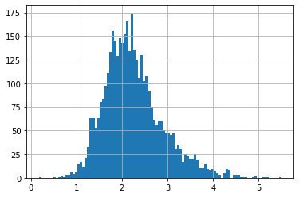

You could then do the same for `v` and start to fit Gaussians to the distributions and select candidates.

**Note** for large queries it is recommened to use the script version of `find_sources.py` to get cutouts for **all** results.

Last update: August 9, 2021  
Created: August 5, 2020